# Predicting Wine Quality Using Physicochemical Properties

Contributors: Jianru Deng, Yuyan Guo, Vignesh Lakshmi Rajakumar, Cameron Harris

## Acknowledgements

The data set was produced by P. Cortez, A. Cerdeira, F. Almeida, T. Matos and J. Reis. Modeling wine preferences by data mining from physicochemical properties. In Decision Support Systems, Elsevier, 47(4):547-553, 2009. It was sourced from Dua, D. and Graff, C. (2019). UCI Machine Learning Repository [http://archive.ics.uci.edu/ml]. Irvine, CA: University of California, School of Information and Computer Science.

All machine learning processing and analysis was done using Sci-kit Learn (Pedregosa et al. (2011)). Tables and figures in this report were created with the help of the Knitr (Xie (2014)) package. File paths were managed using the Here (Müller (2020)) package.

## Data Summary

The goal of the project was to answer the following research question:

> Can we predict if a wine is “good” (6 or higher out of 10) or “bad” (5 or lower out of 10) based on its physicochemical properties alone?

It is important to note that the labels “good” and “bad” are purely for classification and were selected by the relative wine quality scores determined by wine experts and the quality boundary identified during the exploratory data analysis (EDA).

This prediction problem could have been framed as either a multi-class classification, binary classification or regression problem. During EDA, the team found two observations that led us to simplify the problem into a binary classification one (i.e. good vs. bad wine). The first observation, which came from a distribution of the training target values, was that not all classes were well represented for the target values. The second observation was that the majority of wine quality scores were between 4-6. From this information, we decided that a multi-class classification approach would yield poor prediction results and provide little in value in identifying important features for determining wine quality. Whereas with a binary classification, we could better predict which types of chemical and physical characteristics can be attributed to good wines.

Table 1. Sample of processed data used for wine quality prediction

| fixed acidity | volatile acidity | citric acid | residual sugar | chlorides | free sulfur dioxide | total sulfur dioxide | density | pH | sulphates | alcohol | type | target |
| --- | --- | --- | --- | --- | --- | --- | --- | --- | --- | --- | --- | --- |
| 7.4 | 0.70 | 0.00 | 1.9 | 0.076 | 11 | 34 | 0.9978 | 3.51 | 0.56 | 9.4 | red | bad |
| 7.8 | 0.88 | 0.00 | 2.6 | 0.098 | 25 | 67 | 0.9968 | 3.20 | 0.68 | 9.8 | red | bad |
| 7.8 | 0.76 | 0.04 | 2.3 | 0.092 | 15 | 54 | 0.9970 | 3.26 | 0.65 | 9.8 | red | bad |
| 11.2 | 0.28 | 0.56 | 1.9 | 0.075 | 17 | 60 | 0.9980 | 3.16 | 0.58 | 9.8 | red | good |
| 7.4 | 0.70 | 0.00 | 1.9 | 0.076 | 11 | 34 | 0.9978 | 3.51 | 0.56 | 9.4 | red | bad |
| 7.4 | 0.66 | 0.00 | 1.8 | 0.075 | 13 | 40 | 0.9978 | 3.51 | 0.56 | 9.4 | red | bad |
| 7.9 | 0.60 | 0.06 | 1.6 | 0.069 | 15 | 59 | 0.9964 | 3.30 | 0.46 | 9.4 | red | bad |
| 7.3 | 0.65 | 0.00 | 1.2 | 0.065 | 15 | 21 | 0.9946 | 3.39 | 0.47 | 10.0 | red | good |
| 7.8 | 0.58 | 0.02 | 2.0 | 0.073 | 9 | 18 | 0.9968 | 3.36 | 0.57 | 9.5 | red | good |
| 7.5 | 0.50 | 0.36 | 6.1 | 0.071 | 17 | 102 | 0.9978 | 3.35 | 0.80 | 10.5 | red | bad |

Next we analyze the target classes for this data set in the figure below.

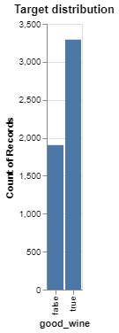

Figure 1. Target Class Distribution

For this classification problem we determined that we could ignore class imbalance related intricacies and could begin splitting the data into train and test sets. For this task, an 80/20 train/test split was used.

## Preprocessing of Features

As mentioned, there were eleven numeric features and one categorical feature. For this analysis, the eleven numeric features were scaled using a standard scalar, which involves removing the mean and scaling to unit variance (Pedregosa et al. (2011)). The categorical feature, wine type, only contained two values (red and white) so it was treated as a binary feature.

## Modelling and Cross Validation Scores

All models were evaluated through five-fold cross validation on the training data set. Accuracy was used as the primary metric to evaluate model performance. For this classification problem, there is low consequence to a false negative or false positive classifications, therefore recall and precision are of low importance to us. Accuracy provides a simple, clear way to compare model performance.

$$\text{Accuracy} = \frac{\text{Number of correct predictions}}{\text{Number of examples}}$$
The following models were evaluated to predict the wine quality label:

- Dummy classifier
- Decision tree
- RBF SVM: SVC
- Logistic Regression
- Random Forest

Table 2. Cross validation scores for models using training dataset

| model | mean_train_accuracy | mean_valid_accuracy | mean_fit_time (s) | mean_score_time (s) | std_train_score | std_valid_score |
| --- | --- | --- | --- | --- | --- | --- |
| DummyClassifier | 0.6336 | 0.6336 | 0.0018 | 0.0011 | 0.0001 | 0.0004 |
| Decision Tree | 1.0000 | 0.7535 | 0.0415 | 0.0065 | 0.0000 | 0.0268 |
| RBF SVM | 0.7943 | 0.7687 | 0.3944 | 0.0553 | 0.0048 | 0.0126 |
| Logistic Regression | 0.7360 | 0.7339 | 0.0225 | 0.0061 | 0.0029 | 0.0072 |
| Random Forest | 1.0000 | 0.8197 | 0.6527 | 0.0282 | 0.0000 | 0.0104 |

The results in Table 2 show that the Random Forest classified the wine quality with the highest accuracy on the training data with a validation score of 0.82. This was not surprising to our team as Random Forest is one of the most widely used and powerful model for classification problems.

The SVC with RBF SVM model performed the next best with a validation score of 0.769.

## Hyperparameter Optimization

Given the cross validation results above, hyperparameter optimization was carried out on our Random Forest model on the number of trees and maximum tree depth parameters.

Table 3. Hyperparameter optimization results

| param_randomforestclassifier__max_depth | param_randomforestclassifier__n_estimators | mean_test_score | std_test_score | rank_test_score |
| --- | --- | --- | --- | --- |
| 17 | 173 | 0.8220093 | 0.0131897 | 1 |
| 17 | 156 | 0.8218170 | 0.0124447 | 2 |
| 15 | 115 | 0.8208538 | 0.0106696 | 3 |
| 19 | 121 | 0.8204707 | 0.0104500 | 4 |
| 16 | 89 | 0.8197000 | 0.0121985 | 5 |

The results of optimization two key hyperparameters resulted in slightly improved validation results (note that in Table 3, “test score” is comparable to “valid score” from Table 2).

## Test Data Scores and Conclusions

Finally, with a Random Forest model containing optimized hyperparameters, we were able to test the accuracy of our model on the test data set.

Table 4. Random Forest scores on test data set

| test_score |
| --- |
| 0.8476923 |

With an optimized, Random Forest model, we were able to achieve an accuracy of 0.848 on the test data set. This is slightly higher than the validation scores using the training data, which tells us that we may have got a bit lucky on the test data set. But overall, the model is doing a decent job at predicting the wine label of “good” or “bad” given the physicochemical properties as features.

If we recall the main research question:

> Can we predict if a wine is “good” (6 or higher out of 10) or “bad” (5 or lower out of 10) based on its physicochemical properties alone?

The results show that with about 85% accuracy, it is possible to predict whether a wine may be considered “good” (6/10 or higher) or “bad” (5/10 or lower).

Some further work that may result in higher prediction accuracy could include feature selection optimization. For example, some of the features seem like they could be correlated (e.g. free sulphur dioxide, total sulphur dioxide, sulphates).

## References

Müller, Kirill. 2020. *Here: A Simpler Way to Find Your Files*. https://CRAN.R-project.org/package=here.

Pedregosa, F., G. Varoquaux, A. Gramfort, V. Michel, B. Thirion, O. Grisel, M. Blondel, et al. 2011. “Scikit-Learn: Machine Learning in Python.” *Journal of Machine Learning Research* 12: 2825–30.

Xie, Yihui. 2014. “Knitr: A Comprehensive Tool for Reproducible Research in R.” In *Implementing Reproducible Computational Research*, edited by Victoria Stodden, Friedrich Leisch, and Roger D. Peng. Chapman; Hall/CRC. http://www.crcpress.com/product/isbn/9781466561595.